# lab9

```python
# let's import the datset
from tensorflow.keras.datasets import fashion_mnist

# loading the dataset
(train_images, train_labels), (test_images, test_labels) = fashion_mnist.load_data()
```

```python
# And print the shape of train_images and test_images to understand the data
print("Shape of train_images:", train_images.shape)
print("Shape of test_images:", test_images.shape)
```

```
Shape of train_images: (60000, 28, 28)
Shape of test_images: (10000, 28, 28)
```

So we have a training set with 60,000 samples and a test set with 10,000 samples, where each sample is an image of 28x28 pixels in size.

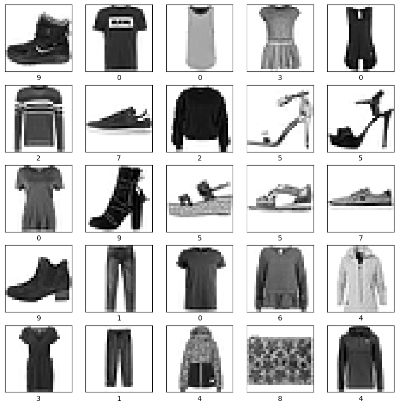

```python
# Also visualize the data
import matplotlib.pyplot as plt

# Displaying few sample images
plt.figure(figsize=(10, 10))
for i in range(25):
    plt.subplot(5, 5, i+1)
    plt.xticks([])
    plt.yticks([])
    plt.grid(False)
    plt.imshow(train_images[i], cmap=plt.cm.binary)
    plt.xlabel(train_labels[i])
plt.show()
```

cool

there seems to be a problem with the train_labels and test_labels features so let's normalize them

```python
from tensorflow.keras.utils import to_categorical

# One hot encoding
train_labels = to_categorical(train_labels, 10)

test_labels = to_categorical(test_labels, 10)

# Output
print("Shape of test_images:", test_images.shape)
print("Shape of test_labels:", test_labels.shape)
```

```
Shape of test_images: (10000, 28, 28)
Shape of test_labels: (10000, 10)
```

```python
import numpy as np

# Checking the range of pixel values
print("Pixel value range in train_images:", np.min(train_images), "-", np.max(train_images))
print("Pixel value range in test_images:", np.min(test_images), "-", np.max(test_images))
```

```
Pixel value range in train_images: 0 - 255
Pixel value range in test_images: 0 - 255
```

lets normalize these pixel values to a range of 0 to 1 by dividing each pixel value by the max-255

```python
#  and Apply min-max scaling too
train_images = train_images.reshape((60000, 28 * 28))

train_images = train_images.astype('float32') / 255

# step 2
test_images = test_images.reshape((10000, 28 * 28))

test_images = test_images.astype('float32') / 255

# Output
print("Shape of test_images:", test_images.shape)
print("Shape of test_labels:", test_labels.shape)
```

```
Shape of test_images: (10000, 784)
Shape of test_labels: (10000, 10)
```

# Training a Dense Neural Network

We will experiment with three different hyperparameter configurations for our neural network training. Below are the details of each configuration:

## Configuration 1: Basic Model

- **Layers**: 1 Hidden Layer
- **Neurons**: 128 in the hidden layer
- **Activation**: ReLU for hidden, Softmax for output
- **Optimizer**: Adam
- **Epochs**: 10
- **Batch Size**: 64

```python
from tensorflow.keras.models import Sequential
from tensorflow.keras.layers import Dense

# Configuration 1: Basic Model
model_1 = Sequential([
    Dense(128, activation='relu', input_shape=(784,)),
    Dense(10, activation='softmax')
])

model_1.compile(optimizer='adam',
                loss='categorical_crossentropy',
                metrics=['accuracy'])

history_1 = model_1.fit(train_images, train_labels, epochs=10, batch_size=64, validation_split=0.2)
```

## Configuration 2: Deeper Model

- **Layers**: 2 Hidden Layers
- **Neurons**: 256 and 128 in the hidden layers
- **Activation**: ReLU for hidden, Softmax for output
- **Optimizer**: SGD
- **Epochs**: 15
- **Batch Size**: 32

```python
# Configuration 2: Deeper Model
model_2 = Sequential([
    Dense(256, activation='relu', input_shape=(784,)),
    Dense(128, activation='relu'),
    Dense(10, activation='softmax')
])

model_2.compile(optimizer='sgd',
                loss='categorical_crossentropy',
                metrics=['accuracy'])

history_2 = model_2.fit(train_images, train_labels, epochs=15, batch_size=32, validation_split=0.2)
```

## Configuration 3: Complex Model

- **Layers**: 3 Hidden Layers
- **Neurons**: 512, 256, and 128 in the hidden layers
- **Activation**: Tanh for hidden, Softmax for output
- **Optimizer**: RMSprop
- **Epochs**: 20
- **Batch Size**: 128

```python
# Configuration 3: Complex Model
model_3 = Sequential([
    Dense(512, activation='tanh', input_shape=(784,)),
    Dense(256, activation='tanh'),
    Dense(128, activation='tanh'),
    Dense(10, activation='softmax')
])

model_3.compile(optimizer='rmsprop',
                loss='categorical_crossentropy',
                metrics=['accuracy'])

history_3 = model_3.fit(train_images, train_labels, epochs=20, batch_size=128, validation_split=0.2)
```

EVALUATION:

```python
# Predict using a small batch from test_images
output = model_1.predict(test_images[:32])
print("Shape of model output:", output.shape)

output = model_2.predict(test_images[:32])
print("Shape of model output:", output.shape)

output = model_3.predict(test_images[:32])
print("Shape of model output:", output.shape)
```

[output not shown]

```python
# Evaluate Model 1
model_1.compile(optimizer='adam', loss='categorical_crossentropy', metrics=['accuracy'])

# Evaluate Model 2
model_2.compile(optimizer='adam', loss='categorical_crossentropy', metrics=['accuracy'])

# Evaluate Model 3
model_3.compile(optimizer='adam', loss='categorical_crossentropy', metrics=['accuracy'])
```

```python
# OUTPUT
test_loss_1, test_acc_1 = model_1.evaluate(test_images, test_labels)
print('Test accuracy for Model 1:', test_acc_1)


test_loss_2, test_acc_2 = model_2.evaluate(test_images, test_labels)
print('Test accuracy for Model 2:', test_acc_2)


test_loss_3, test_acc_3 = model_3.evaluate(test_images, test_labels)
print('Test accuracy for Model 3:', test_acc_3)
```

```
Test accuracy for Model 1: 0.8686000108718872
Test accuracy for Model 2: 0.8700000047683716
Test accuracy for Model 3: 0.8823000192642212
```

## Top Model: Model 3 did the best, with about 88.23% accuracy. It probably did better because it's more complex, maybe having more layers or neurons than the other two models.

## Deep Dive into Model 3: Use Model 3 for more detailed checks since it scored highest. You can make a confusion matrix and look into where it didn't predict correctly.

```python
from sklearn.metrics import confusion_matrix
import numpy as np

# Make predictions with Model 3
predictions_3 = model_3.predict(test_images)
predicted_classes_3 = np.argmax(predictions_3, axis=1)
true_classes = np.argmax(test_labels, axis=1)

#  confusion matrix
cm = confusion_matrix(true_classes, predicted_classes_3)

# OUTPUT
print(cm)
```

```
[[763   0  17  22   5   1 184   0   7   1]
 [  4 976   0  15   2   0   3   0   0   0]
 [ 10   1 810  13  89   1  74   0   2   0]
 [ 19   6  15 898  26   0  31   0   5   0]
 [  0   1 111  27 817   0  41   0   3   0]
 [  0   0   0   0   0 951   1  27   4  17]
 [ 64   1  80  24  91   0 732   0   8   0]
 [  0   0   0   0   0  15   0 971   0  14]
 [  4   0   3   3   1   4   7   3 975   0]
 [  0   0   0   0   0   8   1  61   0 930]]
```

**True Positives on the Diagonal**: The line from the top left corner to the bottom right in the matrix shows correct guesses for each type. Like, the model got 763 right for class 0 and 976 right for class 1, etc.

**Mistakes Off the Diagonal**: Numbers not on this line show errors. For instance, it thought 17 things in class 0 were class 2, and 22 from class 0 were seen as class 3, and so on.

**Looking at Certain Types**:

- **Class 0 (T-shirts/Top)**: Got mixed up with class 6 (shirts) 184 times.
- **Class 2 (Pullovers)**: Often mixed with class 4 (Coats) and class 6.
- **Class 6 (Shirts)**: Lots of mix-ups, especially with class 0, 2, and 4.

**Classes It Nailed**:

- **Class 1 (Trousers)**: Spot on with 976 right and hardly any wrong.
- **Class 5 (Sandals) and Class 7 (Sneakers)**: Mostly got these right too.

**What We Learn**:

- It's great at spotting some types like Trousers, Sandals, and Sneakers.
- Gets confused between things that look alike but are different, like T-shirts and Shirts or Pullovers and Coats.